# R_Markdown

Christopher_Zdyrski

3/13/2021

#This is my R Markdown document to analyze two snp files, combine them and pull out wanted data for further analysis in ggplot2.

###Data Summary ###Get two original files

```r
fang_et_al_genotypes <- read.table('https://raw.githubusercontent.com/EEOB-BioData/BCB546-Spring2021/main/assignments/UNIX_Assignment/fang_et_al_genotypes.txt', header=TRUE, sep="\t",stringsAsFactors = FALSE)

snp_position <- read.table('https://raw.githubusercontent.com/EEOB-BioData/BCB546-Spring2021/main/assignments/UNIX_Assignment/snp_position.txt', header=TRUE, sep="\t", stringsAsFactors = FALSE)
```

###Attributes of fang_et_al_genotypes.txt

```r
dim(fang_et_al_genotypes)
```

```
## [1] 2782  986
```

```r
str(fang_et_al_genotypes)
```

```
## 'data.frame':    2782 obs. of  986 variables:
##  $ Sample_ID     : chr  "SL-15" "SL-16" "SL-11" "SL-12" ...
##  $ JG_OTU        : chr  "T-aust-1" "T-aust-2" "T-brav-1" "T-brav-2" ...
##  $ Group         : chr  "TRIPS" "TRIPS" "TRIPS" "TRIPS" ...
##  $ abph1.20      : chr  "?/?" "?/?" "?/?" "?/?" ...
##  $ abph1.22      : chr  "?/?" "?/?" "?/?" "?/?" ...
##  $ ae1.3         : chr  "T/T" "T/T" "T/T" "T/T" ...
##  $ ae1.4         : chr  "G/G" "?/?" "G/G" "G/G" ...
##  $ ae1.5         : chr  "T/T" "T/T" "T/T" "T/T" ...
##  $ an1.4         : chr  "C/C" "C/C" "?/?" "C/C" ...
##  $ ba1.6         : chr  "?/?" "A/G" "G/G" "G/G" ...
##  $ ba1.9         : chr  "G/G" "G/G" "G/G" "G/G" ...
##  $ bt2.5         : chr  "?/?" "?/?" "C/C" "C/C" ...
##  $ bt2.7         : chr  "A/A" "A/A" "A/A" "A/A" ...
##  $ bt2.8         : chr  "?/?" "?/?" "?/?" "?/?" ...
```

[output cut: 86 more lines]

```r
object.size(fang_et_al_genotypes)
```

```
## 22681376 bytes
```

#By inspecting this file I learned that: #The file is 22681376 bytes. #There are 2783 lines. #There are 986 columns in this file.

###Attributes of snp_position.txt

```r
dim(snp_position)
```

```
## [1] 983  15
```

```r
str(snp_position)
```

```
## 'data.frame':    983 obs. of  15 variables:
##  $ SNP_ID              : chr  "abph1.20" "abph1.22" "ae1.3" "ae1.4" ...
##  $ cdv_marker_id       : int  5976 5978 6605 6606 6607 5982 3463 3466 5983 5985 ...
##  $ Chromosome          : chr  "2" "2" "5" "5" ...
##  $ Position            : chr  "27403404" "27403892" "167889790" "167889682" ...
##  $ alt_pos             : chr  "" "" "" "" ...
##  $ mult_positions      : chr  "" "" "" "" ...
##  $ amplicon            : chr  "abph1" "abph1" "ae1" "ae1" ...
##  $ cdv_map_feature.name: chr  "AB042260" "AB042260" "ae1" "ae1" ...
##  $ gene                : chr  "abph1" "abph1" "ae1" "ae1" ...
##  $ candidate.random    : chr  "candidate" "candidate" "candidate" "candidate" ...
##  $ Genaissance_daa_id  : int  8393 8394 8395 8396 8397 8398 8399 8400 8401 8402 ...
##  $ Sequenom_daa_id     : int  10474 10475 10477 10478 10479 10481 10482 10483 10486 10487 ...
##  $ count_amplicons     : int  1 0 1 0 0 1 1 0 1 0 ...
##  $ count_cmf           : int  1 0 1 0 0 1 0 0 1 0 ...
##  $ count_gene          : int  1 0 1 0 0 1 1 0 1 0 ...
```

```r
object.size(snp_position)
```

```
## 327392 bytes
```

#By inspecting this file I learned that: #The file size is 327392 bytes. #There are 983 lines. #There are 15 columns in this file.

###Data processing

#Install & load tidyverse packages

```r
library(tidyverse)
```

#Seperate out teosinte (ZMPBA, ZMPIL, and ZMPJA) and maize (ZMMIL OR ZMMLR OR ZMMMR) with grep, and also get rid of column two and three, format correctly with tibble command

```r
teosinte_data <- fang_et_al_genotypes[grep("ZMP", fang_et_al_genotypes$Group), ]
maize_data <- fang_et_al_genotypes[grep("ZMM", fang_et_al_genotypes$Group), ]

teosinte_data_excluding_col <- select(teosinte_data, -JG_OTU, -Group)
teosinte_data_excluding_col <- as_tibble(teosinte_data_excluding_col)

maize_data_excluding_col <- select(maize_data, -JG_OTU, -Group)
maize_data_excluding_col <- as_tibble(maize_data_excluding_col)
```

#Swap col names to rows names

```r
swap_teosinte_data_excluding_col <- column_to_rownames(teosinte_data_excluding_col, var="Sample_ID")

swap_maize_data_excluding_col <- column_to_rownames(maize_data_excluding_col, var="Sample_ID")
```

#Transpose both genotype files to swap the rows and columns

```r
transposed_teosinte_data <- t(swap_teosinte_data_excluding_col)
transposed_maize_data <- t(swap_maize_data_excluding_col)

transposed_teosinte_data <- rownames_to_column(as.data.frame(transposed_teosinte_data), var = "SNP_ID")
transposed_maize_data <- rownames_to_column(as.data.frame(transposed_maize_data), var = "SNP_ID")
```

#Crop and make sure snp file is sorted

```r
snp_cropped <- select(snp_position, SNP_ID, Chromosome, Position)

attach(snp_cropped)
sorted_snp_position <- snp_cropped[order(SNP_ID),]
```

#Merge files (maize/teosinte with snp_position file)

```r
teosinte_joined <- merge(sorted_snp_position, transposed_teosinte_data, by="SNP_ID")

teosinte_joined_2 <- filter(teosinte_joined, Chromosome != "multiple" & Chromosome != "unknown")
teosinte_ascending <- arrange(teosinte_joined_2, Position)

maize_joined <- merge(sorted_snp_position, transposed_maize_data, by="SNP_ID")
maize_joined_2 <- filter(maize_joined, Chromosome != "multiple" & Chromosome != "unknown")

maize_ascending <- arrange(maize_joined_2, Position)
```

###Teosinte grep out 10 files, one for each chromosome

```r
teosinte_chrom_1.txt <- teosinte_ascending[grep("1$", teosinte_ascending$Chromosome), ]
teosinte_chrom_2.txt <- teosinte_ascending[grep("2$", teosinte_ascending$Chromosome), ]
teosinte_chrom_3.txt <- teosinte_ascending[grep("3$", teosinte_ascending$Chromosome), ]
teosinte_chrom_4.txt <- teosinte_ascending[grep("4$", teosinte_ascending$Chromosome), ]
teosinte_chrom_5.txt <- teosinte_ascending[grep("5$", teosinte_ascending$Chromosome), ]
teosinte_chrom_6.txt <- teosinte_ascending[grep("6$", teosinte_ascending$Chromosome), ]
teosinte_chrom_7.txt <- teosinte_ascending[grep("7$", teosinte_ascending$Chromosome), ]
teosinte_chrom_8.txt <- teosinte_ascending[grep("8$", teosinte_ascending$Chromosome), ]
teosinte_chrom_9.txt <- teosinte_ascending[grep("9$", teosinte_ascending$Chromosome), ]
teosinte_chrom_10.txt <- teosinte_ascending[grep("10", teosinte_ascending$Chromosome), ]
```

###Teosinte make 2 files, one with the 3 headers, and another to gsub out the “?” then cbind them together, do this for all 10 files

```r
teosinte_chrom_1_hyphen.txt <- arrange(teosinte_chrom_1.txt, desc(Position))
ncol(teosinte_chrom_1_hyphen.txt)
```

```
## [1] 978
```

```r
teosinte_chrom_1_hyphen.txt <- apply(teosinte_chrom_1_hyphen.txt[,4:978], 2, function(teosinte_chrom_1_hyphen.txt) gsub("\\?", "-", teosinte_chrom_1_hyphen.txt))

teosinte_chrom_1.txt_three_col <- teosinte_chrom_1.txt[1:3]
teosinte_chrom_1_hyphen.txt <- cbind(teosinte_chrom_1.txt_three_col, teosinte_chrom_1_hyphen.txt)
```

```r
teosinte_chrom_2_hyphen.txt <- arrange(teosinte_chrom_2.txt, desc(Position))
ncol(teosinte_chrom_2_hyphen.txt)
```

```
## [1] 978
```

```r
teosinte_chrom_2_hyphen.txt <- apply(teosinte_chrom_2_hyphen.txt[,4:978], 2, function(teosinte_chrom_2_hyphen.txt) gsub("\\?", "-", teosinte_chrom_2_hyphen.txt))

teosinte_chrom_2.txt_three_col <- teosinte_chrom_2.txt[1:3]
teosinte_chrom_2_hyphen.txt <- cbind(teosinte_chrom_2.txt_three_col, teosinte_chrom_2_hyphen.txt)
```

```r
teosinte_chrom_3_hyphen.txt <- arrange(teosinte_chrom_3.txt, desc(Position))
ncol(teosinte_chrom_3_hyphen.txt)
```

```
## [1] 978
```

```r
teosinte_chrom_3_hyphen.txt <- apply(teosinte_chrom_3_hyphen.txt[,4:978], 2, function(teosinte_chrom_3_hyphen.txt) gsub("\\?", "-", teosinte_chrom_3_hyphen.txt))

teosinte_chrom_3.txt_three_col <- teosinte_chrom_3.txt[1:3]
teosinte_chrom_3_hyphen.txt <- cbind(teosinte_chrom_3.txt_three_col, teosinte_chrom_3_hyphen.txt)
```

```r
teosinte_chrom_4_hyphen.txt <- arrange(teosinte_chrom_4.txt, desc(Position))
ncol(teosinte_chrom_4_hyphen.txt)
```

```
## [1] 978
```

```r
teosinte_chrom_4_hyphen.txt <- apply(teosinte_chrom_4_hyphen.txt[,4:978], 2, function(teosinte_chrom_4_hyphen.txt) gsub("\\?", "-", teosinte_chrom_4_hyphen.txt))

teosinte_chrom_4.txt_three_col <- teosinte_chrom_4.txt[1:3]
teosinte_chrom_4_hyphen.txt <- cbind(teosinte_chrom_4.txt_three_col, teosinte_chrom_4_hyphen.txt)
```

```r
teosinte_chrom_5_hyphen.txt <- arrange(teosinte_chrom_5.txt, desc(Position))
ncol(teosinte_chrom_5_hyphen.txt)
```

```
## [1] 978
```

```r
teosinte_chrom_5_hyphen.txt <- apply(teosinte_chrom_5_hyphen.txt[,4:978], 2, function(teosinte_chrom_5_hyphen.txt) gsub("\\?", "-", teosinte_chrom_5_hyphen.txt))

teosinte_chrom_5.txt_three_col <- teosinte_chrom_5.txt[1:3]
teosinte_chrom_5_hyphen.txt <- cbind(teosinte_chrom_5.txt_three_col, teosinte_chrom_5_hyphen.txt)
```

```r
teosinte_chrom_6_hyphen.txt <- arrange(teosinte_chrom_6.txt, desc(Position))
ncol(teosinte_chrom_6_hyphen.txt)
```

```
## [1] 978
```

```r
teosinte_chrom_6_hyphen.txt <- apply(teosinte_chrom_6_hyphen.txt[,4:978], 2, function(teosinte_chrom_6_hyphen.txt) gsub("\\?", "-", teosinte_chrom_6_hyphen.txt))

teosinte_chrom_6.txt_three_col <- teosinte_chrom_6.txt[1:3]
teosinte_chrom_6_hyphen.txt <- cbind(teosinte_chrom_6.txt_three_col, teosinte_chrom_6_hyphen.txt)
```

```r
teosinte_chrom_7_hyphen.txt <- arrange(teosinte_chrom_7.txt, desc(Position))
ncol(teosinte_chrom_7_hyphen.txt)
```

```
## [1] 978
```

```r
teosinte_chrom_7_hyphen.txt <- apply(teosinte_chrom_7_hyphen.txt[,4:978], 2, function(teosinte_chrom_7_hyphen.txt) gsub("\\?", "-", teosinte_chrom_7_hyphen.txt))

teosinte_chrom_7.txt_three_col <- teosinte_chrom_7.txt[1:3]
teosinte_chrom_7_hyphen.txt <- cbind(teosinte_chrom_7.txt_three_col, teosinte_chrom_7_hyphen.txt)
```

```r
teosinte_chrom_8_hyphen.txt <- arrange(teosinte_chrom_8.txt, desc(Position))
ncol(teosinte_chrom_8_hyphen.txt)
```

```
## [1] 978
```

```r
teosinte_chrom_8_hyphen.txt <- apply(teosinte_chrom_8_hyphen.txt[,4:978], 2, function(teosinte_chrom_8_hyphen.txt) gsub("\\?", "-", teosinte_chrom_8_hyphen.txt))

teosinte_chrom_8.txt_three_col <- teosinte_chrom_8.txt[1:3]
teosinte_chrom_8_hyphen.txt <- cbind(teosinte_chrom_8.txt_three_col, teosinte_chrom_8_hyphen.txt)
```

```r
teosinte_chrom_9_hyphen.txt <- arrange(teosinte_chrom_9.txt, desc(Position))
ncol(teosinte_chrom_9_hyphen.txt)
```

```
## [1] 978
```

```r
teosinte_chrom_9_hyphen.txt <- apply(teosinte_chrom_9_hyphen.txt[,4:978], 2, function(teosinte_chrom_9_hyphen.txt) gsub("\\?", "-", teosinte_chrom_9_hyphen.txt))

teosinte_chrom_9.txt_three_col <- teosinte_chrom_9.txt[1:3]
teosinte_chrom_9_hyphen.txt <- cbind(teosinte_chrom_9.txt_three_col, teosinte_chrom_9_hyphen.txt)
```

```r
teosinte_chrom_10_hyphen.txt <- arrange(teosinte_chrom_10.txt, desc(Position))
ncol(teosinte_chrom_10_hyphen.txt)
```

```
## [1] 978
```

```r
teosinte_chrom_10_hyphen.txt <- apply(teosinte_chrom_10_hyphen.txt[,4:978], 2, function(teosinte_chrom_10_hyphen.txt) gsub("\\?", "-", teosinte_chrom_10_hyphen.txt))

teosinte_chrom_10.txt_three_col <- teosinte_chrom_10.txt[1:3]
teosinte_chrom_10_hyphen.txt <- cbind(teosinte_chrom_10.txt_three_col, teosinte_chrom_10_hyphen.txt)
```

###Maize grep out 10 files, one for each chromosome

```r
maize_chrom_1.txt <- maize_ascending[grep("1$", maize_ascending$Chromosome), ]
maize_chrom_2.txt <- maize_ascending[grep("2$", maize_ascending$Chromosome), ]
maize_chrom_3.txt <- maize_ascending[grep("3$", maize_ascending$Chromosome), ]
maize_chrom_4.txt <- maize_ascending[grep("4$", maize_ascending$Chromosome), ]
maize_chrom_5.txt <- maize_ascending[grep("5$", maize_ascending$Chromosome), ]
maize_chrom_6.txt <- maize_ascending[grep("6$", maize_ascending$Chromosome), ]
maize_chrom_7.txt <- maize_ascending[grep("7$", maize_ascending$Chromosome), ]
maize_chrom_8.txt <- maize_ascending[grep("8$", maize_ascending$Chromosome), ]
maize_chrom_9.txt <- maize_ascending[grep("9$", maize_ascending$Chromosome), ]
maize_chrom_10.txt <- maize_ascending[grep("10", maize_ascending$Chromosome), ]
```

###Maize make 2 files, one with the 3 headers, and another to gsub out the “?” then cbind them together, to make 10 more maize files

```r
maize_chrom_1_hyphen.txt <- arrange(maize_chrom_1.txt, desc(Position))
ncol(maize_chrom_1_hyphen.txt)
```

```
## [1] 1576
```

```r
maize_chrom_1_hyphen.txt <- apply(maize_chrom_1_hyphen.txt[,4:981], 2, function(maize_chrom_1_hyphen.txt) gsub("\\?", "-", maize_chrom_1_hyphen.txt))

maize_chrom_1.txt_three_col <- maize_chrom_1.txt[1:3]
maize_chrom_1_hyphen.txt <- cbind(maize_chrom_1.txt_three_col, maize_chrom_1_hyphen.txt)
```

```r
maize_chrom_2_hyphen.txt <- arrange(maize_chrom_2.txt, desc(Position))
ncol(maize_chrom_2_hyphen.txt)
```

```
## [1] 1576
```

```r
maize_chrom_2_hyphen.txt <- apply(maize_chrom_2_hyphen.txt[,4:981], 2, function(maize_chrom_2_hyphen.txt) gsub("\\?", "-", maize_chrom_2_hyphen.txt))

maize_chrom_2.txt_three_col <- maize_chrom_2.txt[1:3]
maize_chrom_2_hyphen.txt <- cbind(maize_chrom_2.txt_three_col, maize_chrom_2_hyphen.txt)
```

```r
maize_chrom_3_hyphen.txt <- arrange(maize_chrom_3.txt, desc(Position))
ncol(maize_chrom_3_hyphen.txt)
```

```
## [1] 1576
```

```r
maize_chrom_3_hyphen.txt <- apply(maize_chrom_3_hyphen.txt[,4:981], 2, function(maize_chrom_3_hyphen.txt) gsub("\\?", "-", maize_chrom_3_hyphen.txt))

maize_chrom_3.txt_three_col <- maize_chrom_3.txt[1:3]
maize_chrom_1_hyphen.txt <- cbind(maize_chrom_1.txt_three_col, maize_chrom_1_hyphen.txt)
```

```r
maize_chrom_4_hyphen.txt <- arrange(maize_chrom_4.txt, desc(Position))
ncol(maize_chrom_4_hyphen.txt)
```

```
## [1] 1576
```

```r
maize_chrom_4_hyphen.txt <- apply(maize_chrom_4_hyphen.txt[,4:981], 2, function(maize_chrom_4_hyphen.txt) gsub("\\?", "-", maize_chrom_4_hyphen.txt))

maize_chrom_4.txt_three_col <- maize_chrom_4.txt[1:3]
maize_chrom_4_hyphen.txt <- cbind(maize_chrom_4.txt_three_col, maize_chrom_4_hyphen.txt)
```

```r
maize_chrom_5_hyphen.txt <- arrange(maize_chrom_5.txt, desc(Position))
ncol(maize_chrom_5_hyphen.txt)
```

```
## [1] 1576
```

```r
maize_chrom_5_hyphen.txt <- apply(maize_chrom_5_hyphen.txt[,4:981], 2, function(maize_chrom_5_hyphen.txt) gsub("\\?", "-", maize_chrom_5_hyphen.txt))

maize_chrom_5.txt_three_col <- maize_chrom_5.txt[1:3]
maize_chrom_5_hyphen.txt <- cbind(maize_chrom_5.txt_three_col, maize_chrom_5_hyphen.txt)
```

```r
maize_chrom_6_hyphen.txt <- arrange(maize_chrom_6.txt, desc(Position))
ncol(maize_chrom_6_hyphen.txt)
```

```
## [1] 1576
```

```r
maize_chrom_6_hyphen.txt <- apply(maize_chrom_6_hyphen.txt[,4:981], 2, function(maize_chrom_6_hyphen.txt) gsub("\\?", "-", maize_chrom_6_hyphen.txt))

maize_chrom_6.txt_three_col <- maize_chrom_6.txt[1:3]
maize_chrom_6_hyphen.txt <- cbind(maize_chrom_6.txt_three_col, maize_chrom_6_hyphen.txt)
```

```r
maize_chrom_7_hyphen.txt <- arrange(maize_chrom_7.txt, desc(Position))
ncol(maize_chrom_7_hyphen.txt)
```

```
## [1] 1576
```

```r
maize_chrom_7_hyphen.txt <- apply(maize_chrom_7_hyphen.txt[,4:981], 2, function(maize_chrom_7_hyphen.txt) gsub("\\?", "-", maize_chrom_7_hyphen.txt))

maize_chrom_7.txt_three_col <- maize_chrom_7.txt[1:3]
maize_chrom_7_hyphen.txt <- cbind(maize_chrom_7.txt_three_col, maize_chrom_7_hyphen.txt)
```

```r
maize_chrom_8_hyphen.txt <- arrange(maize_chrom_8.txt, desc(Position))
ncol(maize_chrom_8_hyphen.txt)
```

```
## [1] 1576
```

```r
maize_chrom_8_hyphen.txt <- apply(maize_chrom_8_hyphen.txt[,4:981], 2, function(maize_chrom_8_hyphen.txt) gsub("\\?", "-", maize_chrom_8_hyphen.txt))

maize_chrom_8.txt_three_col <- maize_chrom_8.txt[1:3]
maize_chrom_8_hyphen.txt <- cbind(maize_chrom_8.txt_three_col, maize_chrom_8_hyphen.txt)
```

```r
maize_chrom_9_hyphen.txt <- arrange(maize_chrom_9.txt, desc(Position))
ncol(maize_chrom_9_hyphen.txt)
```

```
## [1] 1576
```

```r
maize_chrom_9_hyphen.txt <- apply(maize_chrom_9_hyphen.txt[,4:981], 2, function(maize_chrom_9_hyphen.txt) gsub("\\?", "-", maize_chrom_9_hyphen.txt))

maize_chrom_9.txt_three_col <- maize_chrom_9.txt[1:3]
maize_chrom_9_hyphen.txt <- cbind(maize_chrom_9.txt_three_col, maize_chrom_9_hyphen.txt)
```

```r
maize_chrom_10_hyphen.txt <- arrange(maize_chrom_10.txt, desc(Position))
ncol(maize_chrom_10_hyphen.txt)
```

```
## [1] 1576
```

```r
maize_chrom_10_hyphen.txt <- apply(maize_chrom_10_hyphen.txt[,4:981], 2, function(maize_chrom_10_hyphen.txt) gsub("\\?", "-", maize_chrom_10_hyphen.txt))

maize_chrom_10.txt_three_col <- maize_chrom_10.txt[1:3]
maize_chrom_10_hyphen.txt <- cbind(maize_chrom_10.txt_three_col, maize_chrom_10_hyphen.txt)
```

#Data Visualization using ggplot #Use pivot longer to neaten up data for ggplot input ##merge fang file with snp_position file

```r
fang_et_al_pivot_longer <- fang_et_al_genotypes %>% pivot_longer(!c(Sample_ID, JG_OTU, Group), names_to="SNP_ID", values_to= "NT")

snp_and_fang_et_al <- merge(fang_et_al_pivot_longer, snp_position, by="SNP_ID")

num_snp_and_fang_et_al <- (snp_and_fang_et_al[!is.na(as.numeric(snp_and_fang_et_al$Chromosome)),])
```

#Make first plot with ggplot, shows SNPs per chromosome using the newly merged file

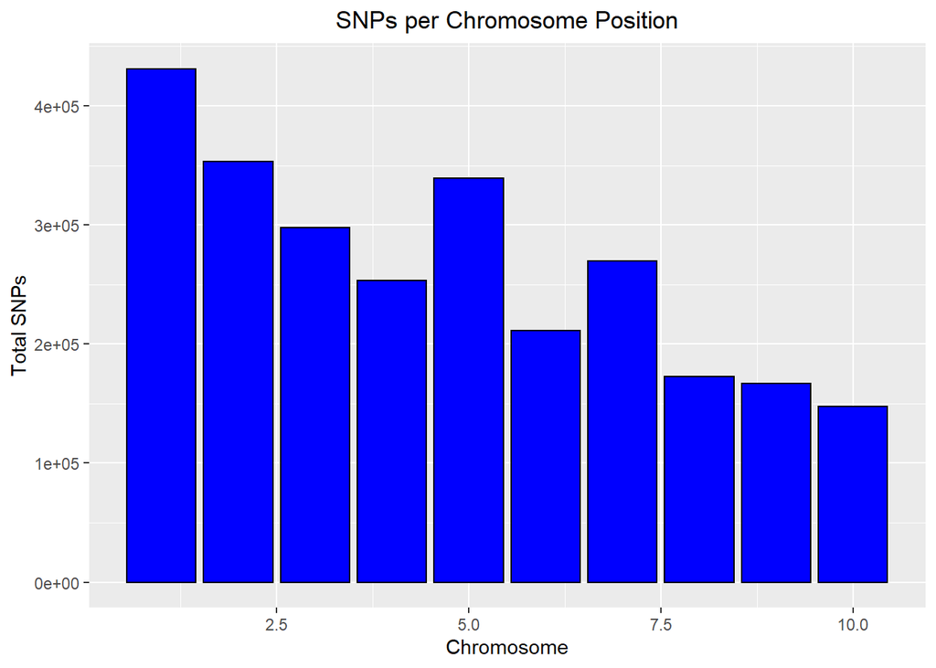

```r
num_snp_and_fang_et_al %>%
  select(SNP_ID, Chromosome, Position) %>%
  drop_na() %>%
  ggplot()+
  geom_bar(mapping = aes(as.numeric(Chromosome)), color="black", fill="blue") +
  labs(x = "Chromosome", y = "Total SNPs") +
  ggtitle("SNPs per Chromosome Position") +
  theme(plot.title = element_text(hjust = 0.5))
```

#Make second plot with ggplot, shows SNP density per chromosome using the newly merged file for both maize and teosinte

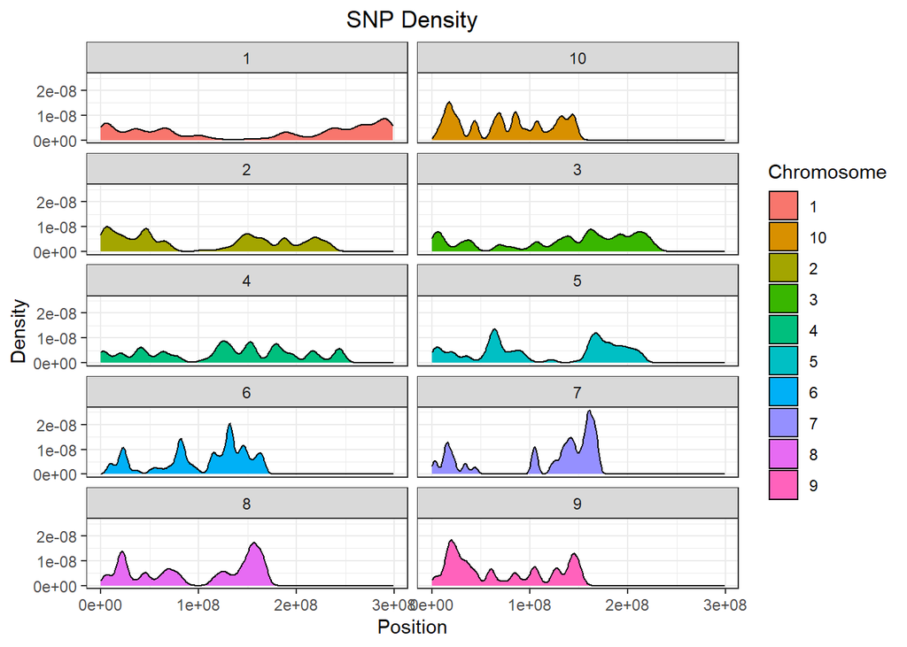

```r
ggplot(num_snp_and_fang_et_al, aes(x= as.numeric(Position))) +
  geom_density(aes(fill = Chromosome)) +
  facet_wrap(~ Chromosome, nrow = 5, ncol = 2) +
  theme_bw() + labs(x = "Position", y = "Density") +
  ggtitle("SNP Density")+
  theme(plot.title = element_text(hjust = 0.5))
```

##ggplot step ##Make a new column called Heterozygotes and then mark all missing rows and all Homozygous rows in the file

```r
hom_het_added_column <- num_snp_and_fang_et_al

hom_het_added_column$Heterozygotes <- "Heterozygotes"

hom_het_added_column$Heterozygotes[hom_het_added_column$NT == "?/?"] <- "Missing"

hom_het_added_column$Heterozygotes[hom_het_added_column$NT %in% c("A/A", "T/T", "C/C", "G/G")] <- "Homozygous"
```

#Make fourth plot with ggplot, uses the heteroyzgosity file from above to display the proportion of heterozygotes in both maize and teosinte

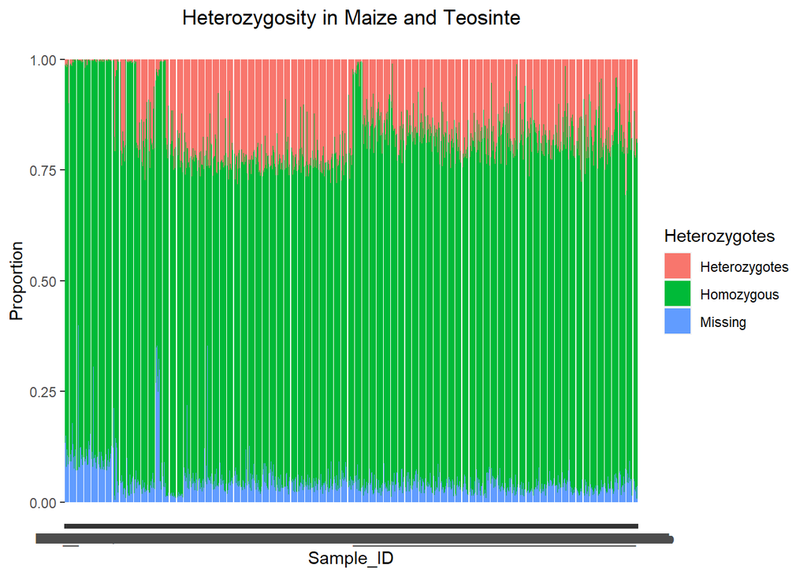

```r
ggplot(hom_het_added_column, aes(x = Sample_ID, fill = Heterozygotes)) +
  geom_bar(position = "fill") +
  labs(x = "Sample_ID", y = "Proportion") +
  ggtitle("Heterozygosity in Maize and Teosinte") +
  theme(plot.title = element_text(hjust = 0.5))
```

#Make fifth plot with ggplot, shows Heterozygosity across al the groups using the newly merged file

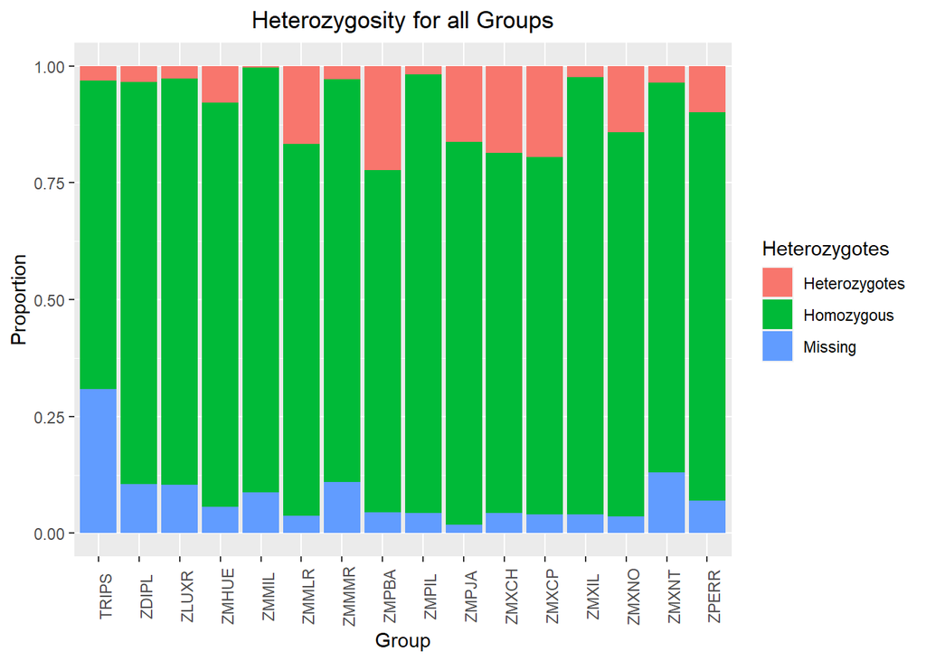

```r
ggplot(hom_het_added_column, aes(x = Group, fill = Heterozygotes)) +
  geom_bar(position = "fill") +
  labs(x = "Group", y = "Proportion") +
  theme(axis.text.x = element_text(angle = 90)) +
  ggtitle("Heterozygosity for all Groups") +
  theme(plot.title = element_text(hjust = 0.5))
```

#Make sixth plot (my plot) with ggplot, I filtered out just Maize and then displayed the Heterozygosity across the three groups using the newly merged file

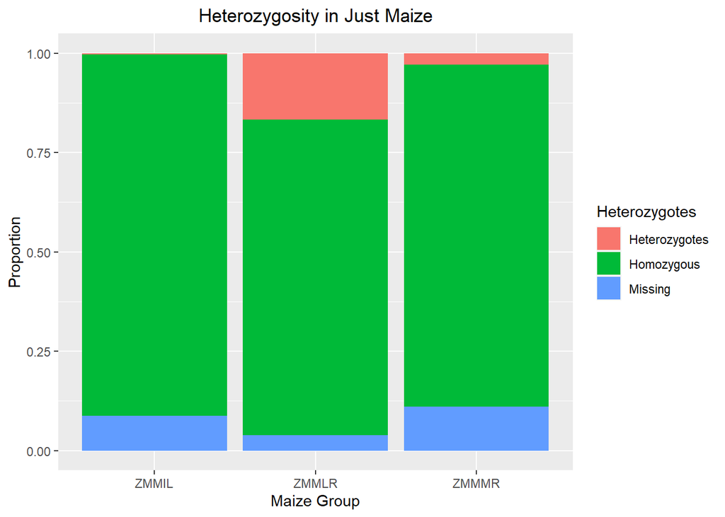

```r
hom_het_added_column_plot <- filter(hom_het_added_column, Group == "ZMMIL" | Group == "ZMMLR" | Group == "ZMMMR")

ggplot(hom_het_added_column_plot, aes(x = Group, fill = Heterozygotes)) +
  geom_bar(position = "fill") +
  labs(x = "Maize Group", y = "Proportion") +
  ggtitle("Heterozygosity in Just Maize") +
  theme(plot.title = element_text(hjust = 0.5))
```